# MG205: Econometrics Theory and Applications

Topic 6: Limitations of Linear Regression

José Ignacio González-Rojas

j.i.gonzalez-rojas@lse.ac.uk

London School of Economics and Political Science

## Today We Examine When OLS Fails

### From Functional Forms to Model Limitations

#### Last week covered

- Polynomial terms for non-linear relationships
- Interaction terms when effects depend on context
- Log transformations for elasticities
- F-tests for multiple restrictions

#### Today’s focus

- When does omitted variable bias matter?
- Prediction vs causal inference
- Reverse causality and simultaneous equations
- Sample selection and non-random sampling

Understanding when OLS breaks down shapes how we interpret every regression

# **Exercise 1:** Does a Commodities Trader Care About Omitted Variables?

## A Trader Predicts Tomorrow’s Oil Price

### A commodities trader builds a model to forecast tomorrow’s oil price

$$\widehat{\text{oil price}}_{t+1} = \hat{\beta}_0 + \hat{\beta}_1 \cdot \text{inventory}_{t}$$

She omits variables like geopolitical tensions, OPEC decisions, and dollar strength.

Should she worry about omitted variable bias?

The answer depends entirely on her objective

## Two Models Serve Fundamentally Different Purposes

### Forecasting vs Understanding Causation

#### Linear Projection (Prediction)

$$y = x'\beta + e$$

$$\mathbb{E}[x \cdot e] = 0$$

- Finds best linear predictor
- Orthogonality holds by construction
- **Goal:** minimise forecast error
- Include anything that helps predict $y$

#### Linear Regression (Causal)

$$y = x'\beta + e$$

$$\mathbb{E}[e | x] = 0$$

- Estimates causal effects
- Exogeneity is an assumption
- **Goal:** understand how $x$ affects $y$
- Include only confounders

## Orthogonality Is Weaker Than Exogeneity

### The Mathematical Distinction

#### Projection **guarantees** unconditional orthogonality

$$\mathbb{E}[x \cdot e] = 0$$

- Errors uncorrelated with $x$ on average
- Automatic from minimising squared prediction error

#### Causal regression **requires** conditional mean independence

$$\mathbb{E}[e | x] = 0$$

- Error has zero mean at every value of $x$
- This is an assumption about the world

Exogeneity $\implies$ Orthogonality, but not the reverse

## The Trader Cares About Accuracy, Not Causation

### Why Omitted Variables Don’t Matter for Prediction

#### Her objective

- Predict $\text{oil price}_{t+1}$ accurately
- Minimise $(y_{t+1} - \hat{y}_{t+1})^2$
- Make profitable trades

#### What projection delivers

- Best linear forecast given information
- Optimal combination of available data
- Correlation is sufficient

#### What she does NOT need

- Causal effect of inventory on price
- Understanding of market mechanisms
- Unbiased structural parameters

#### What happens when we omit OPEC decisions?

- May reduce forecast accuracy
- But doesn’t create “bias”
- Her $\hat{\beta}_1$ captures predictive relationship

Omitted variable bias is a causal concept—it has no meaning in pure prediction

## Identification, Estimation, and Inference

### Why the Distinction Matters for Our Trader

| Goal | Requires Causation? | Model Needed |
| --- | --- | --- |
| **Predict** oil price tomorrow | No | Projection |
| **Understand** what drives prices | Yes | Regression |

#### The trader’s situation

- She wants accurate forecasts, not causal mechanisms
- Omitting OPEC decisions may reduce accuracy, but doesn’t create “bias”
- Projection coefficients capture predictive relationships—that’s enough

For forecasting, causal identification is irrelevant

# **Exercise 2:** An NGO Targets Its Campaign

## Reaching the Maximum Number of People

### The NGO’s Problem

An NGO wants to maximise reach for a health campaign. They model:

$$\widehat{\text{reach}}_i = \hat{\beta}_0 + \hat{\beta}_1 \cdot \text{social media budget}_i + \hat{\beta}_2 \cdot \text{demographics}_i$$

They omit variables like local trust in institutions, existing health infrastructure, and cultural factors.

#### Their objective

Allocate budget to locations where predicted reach is highest.

## Prediction vs Evaluation Require Different Models

### Same Data, Different Questions

#### Identify high-reach locations (prediction)

- Include all predictive variables
- Omitted variables reduce accuracy
- No causal interpretation needed
- Projection model sufficient

$$\mathbb{E}[x \cdot e] = 0 \; \checkmark$$

#### Measure campaign effectiveness(causal)

- Must control for confounders
- Omitted variables create bias
- Need causal interpretation
- Regression model required

$$\mathbb{E}[e | x] = 0 \; \text{(required)}$$

The same organisation may need both models for different decisions

## When Would OVB Matter for the NGO?

### Shifting from Prediction to Causation

#### Prediction question (correlation sufficient)

“Where should we allocate next year’s budget for maximum reach?”

- Historical data predicts well
- No causal mechanism needed
- Omitted variables reduce fit, not create bias

#### Causal question (exogeneity required)

“Does increasing social media budget cause higher reach?”

- Need to isolate budget effect
- Omitting trust/infrastructure biases estimate
- Policy conclusions require causal model

Always ask: **“Am I trying to predict or to understand causation?”**

# **Exercise 4:** Training and Productivity

## We Want to Change the World, Not Just Describe It

### The Policy Motivation

#### The firm’s question

“If we increase training, will productivity rise?”

#### What we estimate

$$\text{productivity}_i = \beta_0 + \beta_1 \cdot \text{training}_i + e_i$$

#### What we find

$$\hat{\beta}_1 = 0.15 \quad (p < 0.01)$$

“Each hour of training associated with 0.15 unit productivity increase”

#### The problem

- Association $\neq$ causation
- What if estimate is biased?

## Firm Size Confounds the Relationship

### The Causal Structure

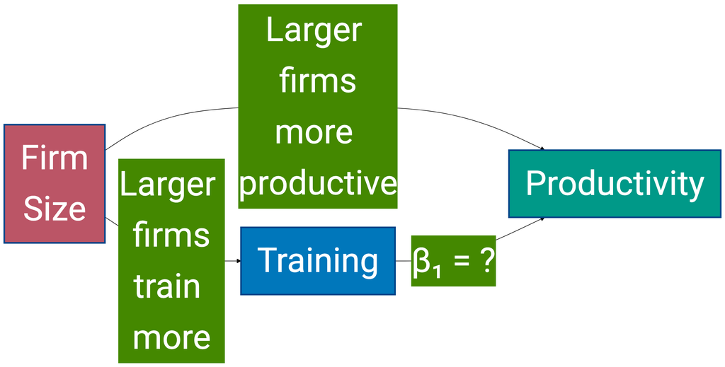

#### Two correlations contaminate our estimate

- Larger firms invest more in training (economies of scale in HR)
- Larger firms are more productive (market power, better technology)

## Our Estimate Captures More Than Training Effects

### Decomposing What $\hat{\beta}_1$ Measures

$$\mathbb{E}[\hat{\beta}_1] = \underbrace{\beta_1}_{\text{true training effect}} + \underbrace{\gamma_2 \cdot \delta_1}_{\text{firm size effect}}$$

where:

- $\gamma_2 > 0$: firm size increases productivity
- $\delta_1 > 0$: training correlates with firm size

$$\text{Bias} = (+) \times (+) = (+)$$

Our estimate $\hat{\beta}_1$ overstates the true training effect

## Why Correlation Fails for Policy

### Unless we change firm size, training alone won’t change productivity

**What our estimate tells us**

Firms with more training have higher productivity.

**What it does NOT tell us**

Giving more training will increase productivity.

**The reality**

- The relationship is driven by firm size
- Smaller firms that increase training won’t see gains
- **The causal path is:** Size → Productivity and Size → Training
- **There is no direct:** Training → Productivity (or it’s much smaller)

## An Alternative Story Reveals the Problem

### Same Data, Different Mechanism

#### Story A (what we assumed)

- Training develops skills → Skills increase output → Productivity rises

#### Story B (what’s actually happening)

- Large firms have resources → Resources fund training programmes
- Large firms have market power → Market power increases profits/productivity

#### Both stories generate

$$\text{cov}(\text{training}, \text{productivity}) > 0$$

Without controlling for firm size, we cannot distinguish these stories

# **Exercise 5:** Does Beauty Cause Higher Wages?

## The Reverse Causality Problem

### Two Plausible Causal Directions

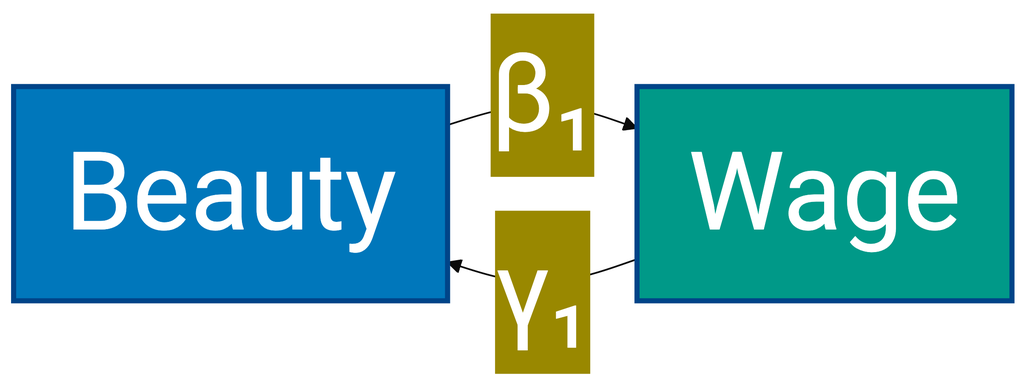

1. Beauty → Wages
- Taste-based discrimination by employers
- Customer preferences in service industries
- Productivity benefits (confidence, social skills)
2. Wages → Beauty
- Higher earners afford better skincare, cosmetics
- Access to aesthetic procedures
- Better health investments

## Cross-Sectional Data Cannot Separate These Effects

### Why Exogeneity Fails

#### We estimate

$$\text{wage}_i = \beta_0 + \beta_1 \cdot \text{beauty}_i + e_i$$

#### But the error contains

$$e_i = \gamma_1 \cdot \text{wage}_i + \text{other factors}$$

#### Therefore

$$\mathbb{E}[e_i | \text{beauty}_i] = \mathbb{E}[\gamma_1 \cdot \text{wage}_i | \text{beauty}_i] \neq 0$$

Beauty correlates with the error because wages affect both

## A Solution: Exploit the Arrow of Time

### The Future Cannot Cause the Present

#### The identification strategy

Compare:

- Today’s beauty rating
- Tomorrow’s wage change

$$\Delta\text{wage}_{i,t+1} = \beta_0 + \beta_1 \cdot \text{beauty}_{it} + e_{it}$$

#### Why this works

- Future wage changes cannot affect current beauty
- Removes reverse causality channel

#### What we identify

$$\beta_1 = \frac{\text{cov}(\text{beauty}_t, \Delta\text{wage}_{t+1})}{\text{var}(\text{beauty}_t)}$$

- Effect of beauty on future wage growth
- Temporal ordering establishes direction
- More credible causal interpretation

Using time as a natural ordering helps establish causality

# **Exercise 6:** Does Health Cause Higher Earnings?

## The Same Simultaneity Problem

### Defining the Variables Precisely

$$\text{earnings}_i = \beta_0 + \beta_1 \cdot \mathbb{1}[i \text{ is healthy}] + e_i$$

## Two-Way Causation Creates Identification Failure

### The Causal Structure

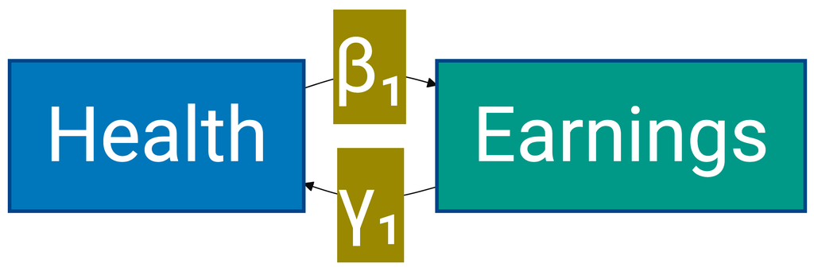

1. Health → Earnings
   - Healthier workers more productive
   - Fewer absences, more energy
   - Better cognitive function
2. Earnings → Health
   - Higher earners afford better healthcare
   - Less financial stress improves health
   - Better nutrition and living conditions

## The Solution Mirrors Exercise 5

### Exploit Temporal Ordering

#### Strategy

$$\Delta\text{earnings}_{i,t+1} = \beta_0 + \beta_1 \cdot \mathbb{1}[i \text{ is healthy at } t] + e_{it}$$

#### Interpretation

- Current health predicts future earnings changes
- Future earnings changes cannot cause current health
- Temporal precedence establishes causal direction

The arrow of time provides identification when simultaneity threatens

# **Exercise 7:** i.i.d. Sampling vs Exogeneity

## AS2 and AS5 Serve Different Purposes

### Both can fail independently

#### AS2: Random Sampling

$$\text{cov}(y_i, y_j) = 0 \text{ for } i \neq j$$

- About **data collection**
- Ensures sample represents population
- Affects **inference** (standard errors)
- **Violated by:**
  - Clusters
  - Time series

#### AS5: Exogeneity

$$\mathbb{E}[e_i | x_i] = 0$$

- About **model specification**
- Ensures no confounding
- Affects **identification** (bias)
- **Violated by:**
  - Omitted variables
  - Reverse causality

## Crucial Terminology: Parameters, Estimators, Estimates

### Getting the Language Right

#### Parameter (Estimand)

$$\beta_1$$

- Population quantity
- Fixed, unknown value
- Identified or not

#### Estimator

$$\hat{\beta}_1 = \frac{\widehat{\text{cov}}(x,y)}{\widehat{\text{var}}(x)}$$

- Function of data
- Random variable
- Biased or unbiased

#### Estimate

$$\hat{\beta}_1 = 0.073$$

We say “biased estimator”—never “biased parameter” or “biased estimate”

## Which Assumptions Enable What?

| Assumption | Statement | Ident. | Estim. | Infer. |
| --- | --- | --- | --- | --- |
| 1 | Linearity: $y = \beta_0 + \beta_1 x + e$ | ✓ | ✓ |  |
| 2 | Random sampling |  | ✓ | ✓ |
| 3 | Variation in $x$: $\text{var}(x) > 0$ | ✓ | ✓ |  |
| 4 | Zero mean: $\mathbb{E}[e] = 0$ | ✓ | ✓ |  |
| 5 | Exogeneity: $\mathbb{E}[e \mid x] = 0$ | ✓ | ✓ |  |
| 6 | Homoskedasticity: $\text{var}(e \mid x) = \sigma^2$ |  |  | ✓ |
| 7 | Normality: $e \sim N(0, \sigma^2)$ |  |  | ✓ |

AS1-AS5: Are we estimating something meaningful? AS6-AS7: Is our uncertainty correct?

# **Exercise 8:** Earnings and School Desk Assignment

## The Alumni Meeting Problem

$$\text{earnings}_i = \beta_0 + \beta_1 \cdot \text{desk number}_i + e_i$$

### Lower desk numbers (front of class) → higher earnings

$$\begin{align*}
H_{0}: \beta_1 = 0 \\
H_{1}: \beta_1 < 0
\end{align*}$$

### What seems fine

- Desk assignment was random
- No omitted variable bias
- No reverse causality

### The sampling method

Survey conducted at alumni meeting

### Who attends alumni meetings?

- Successful graduates
- Those with high earnings
- Want to showcase success

## Sample Selection Along the Dependent Variable

### Non-Random Sampling Creates Bias

$\mathbb{P}[i\text{ attended meeting} | \text{earnings}_i] \text{ is increasing in earnings}$

**Why this biases our estimate**

If $\beta_1 < 0$ (front seats → higher earnings):

- **Front-seat alumni:** High earnings → likely to attend
- **Back-seat alumni:** Lower earnings → less likely to attend

**The consequence**

- We oversample successful back-seat students (the exceptions) and undersample unsuccessful front-seat students.
- This creates **positive bias**: $\mathbb{E}[\hat{\beta}_1] > \beta_1$

## Random treatment assignment doesn’t help when sample selection depends on the outcome

### Who Shows Up to the Meeting?

#### Population relationship

- **Front seats:** Mix of high and low earners
- **Back seats:** Mix of high and low earners
- **True slope:** $\beta_1 < 0$

#### What we’d estimate with random sample

$$\hat{\beta}_1 \approx \beta_1 < 0$$

#### Meeting attendees (selected sample)

- **Front seats:** Mostly high earners (typical)
- **Back seats:** Only high earners (atypical)
- **Selected slope:** Flatter (closer to zero)

#### What we estimate

$$\hat{\beta}_1 > \beta_1$$

Bias is positive, toward zero

Random treatment assignment doesn’t help when sample selection depends on the outcome

# **Measurement Error:** When Variables Contain Noise

## Real Data Is Never Perfectly Measured

### Two Distinct Sources of Error

#### Measurement error in $y$

$$y = y^* + e_0$$

- Observed $y$ differs from true $y^*$
- Examples: self-reported income, recalled consumption

#### Measurement error in $x$

$$x = x^* + e_1$$

- Observed $x$ differs from true $x^*$
- Examples: ability proxied by test scores, beauty rated by juries

These two types have fundamentally different consequences

# **Exercise 9:** Beauty and Wages

## Jury Ratings of Beauty Contain Error

### The Empirical Setup

#### Data

- **Wages**: Measured precisely (administrative records)
- **Beauty**: Measured with error (jury ratings)

#### Estimates based on 3,000 workers

$$\widehat{\text{wages}}_i = \underset{(0.66)}{3.15} - \underset{(0.33)}{0.71} \cdot \mathbb{1}[\text{beauty}_{i} < \overline{\text{beauty}}]$$

#### The problem

- Juries make mistakes in both directions
  - Some truly below-average rated as average
  - Some truly average rated as below-average

Can we conclude that below-average looking people earn less?

## Measurement Error in $x$ Causes Attenuation Bias

$$\text{plim}(\hat{\beta}_1) = \beta_1 \cdot \underbrace{\frac{\text{var}(x^*)}{\text{var}(x^*) + \text{var}(e_1)}}_{\lambda \in (0,1)}$$

#### Direction preserved, magnitude reduced

- $\lambda$ is always between 0 and 1
  - $\hat{\beta}_1$ is shrunk toward zero
- More noise $e_1$ → smaller $\lambda$ → more shrinkage

#### For our beauty coefficient

- True $\beta_{\text{below}} < 0$ (negative effect)
- $\hat{\beta}_{\text{below}} = -0.71$
- Since $\lambda < 1$: $|\hat{\beta}| < |\beta|$
- True effect is **more negative** than $-0.71$

Our estimate is an upper bound on the true (negative) effect

## Testing the Hypothesis Despite Measurement Error

### Test setup

- $H_0: \beta_{\text{below}} = 0$
- $H_1: \beta_{\text{below}} \neq 0$
- Two-sided test at $\alpha = 0.05$

### Results

- $\hat{\beta}_{\text{below}} = -0.71$
- $\text{SE} = 0.33$
- $t = \frac{-0.71 - 0}{0.33} = -2.15$
- $|t| = 2.15 > 1.96$

### Decision

- Reject $H_0$ at $\alpha = 0.05$
- **Why we’re confident:**
  - Without measurement error, $|\hat{\beta}|$ would be **larger**
  - $|t|$ would be **larger**
  - We would reject **even more strongly**

Attenuation makes our test conservative

## The Intuition: Attenuation Gives Us a Bound

### Our Estimate Understates the True Effect

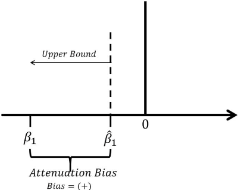

True $\beta_1$ is more negative than our estimate—draw on whiteboard

#### Conservative inference

- $\hat{\beta}_1 = -0.71$ is **closer to zero** than truth
- If we reject $H_0: \beta = 0$, true effect is **at least** this large

# **Exercise 10:** Education and Wages

## Measurement Error in Both Variables

### The Setup

$$\widehat{\log(\text{wages})}_i = \underset{(1.3)}{3.2} + \underset{(0.2)}{0.4} \cdot \text{education}_i$$

$n = 2{,}000$

#### Sources of error

- **Wages**: Self-reported (recall error)
- **Education**: Misremembered years

#### Three parts

1. Test $H_0: \beta_{\text{educ}} = 0$ vs $H_1: \beta_{\text{educ}} > 0$
2. Effect of less error in wages?
3. Effect of less error in education?

## Part (a): Testing Education Effect

### One-Sided Hypothesis Test

#### Test setup

- $H_0: \beta_{\text{educ}} = 0$
- $H_1: \beta_{\text{educ}} > 0$ (one-sided—theory predicts positive)
- One-sided test at $\alpha = 0.05$
- Critical value $c = 1.645$

#### Results

- $\hat{\beta}_{\text{educ}} = 0.4$
- $\text{SE} = 0.2$
- $t = \frac{0.4 - 0}{0.2} = 2.0$
- $t = 2.0 > 1.645$
- **Decision:** Reject $H_0$ at $\alpha = 0.05$
- **Interpretation:** Significant evidence that education increases wages.

## Part (b): Less Error in Wages

### Measurement Error in $y$ Affects Precision, Not Bias

#### When $y = y^* + e_0$, we estimate:

$$y = \beta_0 + \beta_1 x^* + \underbrace{(e + e_0)}_{\upsilon}$$

#### Effect on variance

$$\text{var}(\upsilon) = \text{var}(e) + \text{var}(e_0)$$

- Composite error has larger variance
- $\hat{\sigma}^2$ larger → SE larger → $t$ smaller

#### If wages measured with less error

- $\text{var}(e_0) \downarrow$
- $\text{var}(\upsilon) \downarrow$
- SE $\downarrow$
- $t \uparrow$
- **Still reject, with lower $p$-value**

Error in $y$ does NOT bias $\hat{\beta}$—only inflates variance

## Part (c): Less Error in Education

### Measurement Error in $x$ Affects Both Bias and Variance

$$\text{plim}(\hat{\beta}_1) = \beta_1 \cdot \frac{\text{var}(x^*)}{\text{var}(x^*) + \text{var}(e_1)}$$

#### If education measured with less error

- $\text{var}(e_1) \downarrow$
- Attenuation factor $\lambda \uparrow$ (closer to 1)
- $\hat{\beta}_1 \uparrow$ (closer to true $\beta_1$)

#### Effect on test

- Since $\beta_1 > 0$: estimate increases
- $t = \hat{\beta}_1 / \text{SE}$ increases
- **Still reject, with lower $p$-value**

Both types of reduced error strengthen our conclusion

# **Exercise 11:** Error in $y$ vs Error in $x$

## A Fundamental Distinction

### “Measurement error in the independent variable is a serious problem. Measurement error in the dependent variable is not.” ✅

|  | Error in $y$ | Error in $x$ |
| --- | --- | --- |
| **What happens** | $\text{var}(\upsilon) \uparrow$ | Attenuation bias |
| **Bias?** | **No** | **Yes** (toward zero) |
| **Efficiency?** | Reduced | — |
| **Assumption violated** | None | AS5 (exogeneity) |

## Why Error in $y$ Doesn’t Cause Bias

### Exogeneity preserved → OLS unbiased Full derivation

#### Setup

- True: $y^* = \beta_0 + \beta_1 x^* + e$
- Observed: $y = y^* + e_0$ where $\text{cov}(e_0, x^*) = 0$

#### Substitution

$$y = \beta_0 + \beta_1 x^* + \underbrace{(e + e_0)}_{\upsilon}$$

#### Check exogeneity

$$\text{cov}(x^*, \upsilon) = \text{cov}(x^*, e) + \text{cov}(x^*, e_0) = 0 + 0 = 0 \; \checkmark$$

## Why Error in $x$ Causes Bias

### Exogeneity violated → OLS biased Full derivation

#### Setup

- True: $y^* = \beta_0 + \beta_1 x^* + e$
- Observed: $x = x^* + e_1$, so $x^* = x - e_1$

#### Substitution

$$\begin{align*}
y^{*} &= \beta_0 + \beta_1(x - e_1) + e \\
&= \beta_0 + \beta_1 x + \underbrace{(e - \beta_1 e_1)}_{\upsilon}
\end{align*}$$

#### Check exogeneity

$$\begin{align*}
\text{cov}(x, \upsilon) &= \text{cov}(x^* + e_1, e - \beta_1 e_1) \\
&= -\beta_1 \text{var}(e_1) \neq 0 \; \text{✗}
\end{align*}$$

## Deriving the Attenuation Factor

### From Violated Exogeneity to Bias Formula Full derivation

$$\text{plim}(\hat{\beta}_1) = \frac{\text{cov}(x, y)}{\text{var}(x)} = \frac{\beta_1 \text{var}(x^*)}{\text{var}(x^*) + \text{var}(e_1)}$$

#### The attenuation factor

$$\lambda = \frac{\text{var}(x^*)}{\text{var}(x^*) + \text{var}(e_1)}$$

- Signal-to-total-variance ratio
- More noise → smaller $\lambda$

#### Properties

- As $\text{var}(e_1) \to 0$: $\lambda \to 1$
- As $\text{var}(e_1) \to \infty$: $\lambda \to 0$
- Bias is **predictable** in direction
- Estimate always **toward zero**

# **Exercise 12:** Why Attenuation Isn’t Catastrophic

## The Silver Lining of Measurement Error in $x$

### Why This Bias Is Manageable

#### What we know for certain

$$|\text{plim}(\hat{\beta}_1)| < |\beta_1|$$

- Estimate closer to zero than truth
- Sign of true effect preserved
- Magnitude underestimated

#### What this means for testing

If we **reject** $H_0: \beta_1 = 0$:

- True effect **definitely exists**
- True effect **at least as large** as estimate
- We have a **lower bound** on $|\beta|$

Attenuation provides interpretable bounds—rejection is strong evidence

## Summary: Measurement Error

### Two Problems, Two Different Severities

| Aspect | Error in $y$ | Error in $x$ |
| --- | --- | --- |
| **Primary effect** | ↑ variance | Bias toward zero |
| **Estimator property** | Unbiased, inefficient | Biased, but bounded |
| **Can trust $\hat{\beta}$?** | Yes | Direction yes, magnitude no |
| **Can trust rejection?** | Yes | Yes (conservative) |

Error in $x$ more serious, but attenuation gives us something useful

# **Heteroskedasticity:** Non-Constant Error Variance

## A Different Kind of Problem

### Not About Bias—About Inference

#### Homoskedasticity (AS6)

$$\text{var}(e_i | x_i) = \sigma^2 \quad \forall i$$

- Same variance everywhere
- One parameter describes all errors

#### Heteroskedasticity

$$\text{var}(e_i | x_i) = \sigma_i^2$$

- Variance depends on $x$
- Different spread at different values

This doesn’t bias OLS—but it breaks our standard errors

# **Exercise 13:** Firm Profitability and Sales

## The Model and Interpretation

### Setup

$$\text{profits}_i = \beta_0 + \beta_1 \cdot \log(\text{sales}_i) + e_i$$

where profits measured in millions of dollars.

#### Interpretation of $\hat{\beta}_1$

- Log-level specification
- 1% ↑ in sales → $\hat{\beta}_1 / 100$ million more profit
- Or: 1% ↑ sales → $\hat{\beta}_1 \times 10{,}000$ dollars more profit

#### The heteroskedasticity concern

Larger firms likely have more variable profits:

$$\text{var}(e_i | \text{sales}_i) = \sigma_i^2$$

increasing in sales

## OLS Remains Unbiased Under Heteroskedasticity

### Coefficients are right—but we don’t know how precise they are

#### Unbiasedness requires AS1-AS5 only

1. ✓ Linearity
2. ✓ Random sampling
3. ✓ Variation in $x$
4. ✓ $\mathbb{E}[e] = 0$
5. ✓ $\mathbb{E}[e|x] = 0$

**None involve error variance**

$\therefore$ OLS still unbiased

#### What requires AS6

- Variance formula for $\hat{\beta}$
- Standard errors
- $t$-statistics
- Confidence intervals
- $p$-values

**All inference machinery**

# **Exercise 14:** What Goes Wrong and The Solution

## The Standard Variance Formula Assumes Constant Variance

### Under Homoskedasticity

$$\text{var}(\hat{\beta}_1) = \frac{\sigma^2}{\sum_{i=1}^n (x_i - \bar{x})^2}$$

#### This formula requires

- One $\sigma^2$ for all observations
- We estimate $\hat{\sigma}^2 = \frac{1}{n-k-1}\sum \hat{\varepsilon}_i^2$
- Plug in and compute SE

#### Under heteroskedasticity

- No single $\sigma^2$ exists
- Using wrong formula
- SE incorrect
- All inference invalid

## The True Variance Under Heteroskedasticity

### A More General Formula

$$\text{var}(\hat{\beta}_1) = \frac{\sum_{i=1}^n (x_i - \bar{x})^2 \sigma_i^2}{\left[\sum_{i=1}^n (x_i - \bar{x})^2\right]^2}$$

#### What this formula says

- Each observation weighted by $(x_i - \bar{x})^2$
- Each observation has own $\sigma_i^2$
- Cannot simplify to standard formula

#### The problem

- We don’t know individual $\sigma_i^2$
- Standard software computes wrong thing
- Need different approach

## What Happens If We Use Wrong Formula?

### Direction of Error Depends on Pattern

**If variance increases with $|x - \bar{x}|$:**

- Standard SE **too small**
- $t$-statistics **too large**
- $p$-values **too small**
- Reject $H_0$ too often → **overconfident**

**If variance decreases with $|x - \bar{x}|$:**

- Standard SE **too large**
- $t$-statistics **too small**
- $p$-values **too large**
- Fail to reject too often → **underpowered**

Using wrong SE can go either direction—we can’t know without checking

## Robust Standard Errors: The Solution

### Heteroskedasticity-Consistent Variance Estimator

$$\widehat{\text{var}}_{\text{robust}}(\hat{\beta}_1) = \frac{\sum_{i=1}^n (x_i - \bar{x})^2 \hat{\varepsilon}_i^2}{\left[\sum_{i=1}^n (x_i - \bar{x})^2\right]^2}$$

#### How it works

- Uses $\hat{\varepsilon}_i^2$ to estimate $\sigma_i^2$
- Each residual estimates its own variance
- No constant variance assumption needed

#### Properties

- Consistent under heteroskedasticity
- Valid under homoskedasticity too
- **Always safe to use**
- Standard in applied work

# Summary

## Six Lessons About LR Limitations

#### 1. Projection requires $\mathbb{E}[xe] = 0$, while regression requires $\mathbb{E}[e|x] = 0$

- OVB irrelevant for forecasting

#### 2. Correlation of $z$ with both $x$ and $y$ creates confounding

- Policy based on correlation will fail

#### 3. Reverse causality violates AS5

- **Simultaneity:**
  - beauty ↔︎ wages
  - health ↔︎ earnings
- **One solution:** exploit temporal ordering

#### 4. Non-random sampling violates AS2

- Selection on $y$ distorts relationship

#### 5. Terminology matters

- **Parameters:** identified or not
- **Estimators:** biased or unbiased
- **Estimates:** neither

#### 6. Random sampling affects inference, while exogeneity affects identification

- Both can fail independently

## Four Key Lessons

### What We Learned Today

#### Measurement Error

1. **Error in $y$**: Increases variance, no bias
   - OLS unbiased but inefficient
   - Valid inference with larger SE
2. **Error in $x$**: Causes attenuation bias
   - Estimate shrunk toward zero
   - But gives interpretable bounds
   - Rejection is conservative

#### Heteroskedasticity

3. **Effect**: Doesn’t bias OLS
   - Only affects inference
   - Standard SE formula wrong
4. **Solution**: Robust standard errors
   - Valid whether or not heteroskedasticity present
   - Always use in cross-sections

## Next Class: Exercises 9-14

### Measurement Error, Heteroskedasticity, and Applications

**What we’ll cover**

- **Measurement error:** Bias when $x$ measured with noise
- **Heteroskedasticity:** Non-constant error variance

**Why it matters**

- Real data always contains measurement error
- Heteroskedasticity ubiquitous in cross-sections
- Robust standard errors as practical solution
- Distinguishing bias problems from inference problems

Understanding which assumption fails guides the solution

# **Appendix:** Mathematical Derivations

## Error in $y$: Full Derivation

### Proving OLS Remains Unbiased

#### Setup

- True model: $y^* = \beta_0 + \beta_1 x^* + e$ with $\mathbb{E}[e|x^*] = 0$
- Observed: $y = y^* + e_0$
- Assume: $\text{cov}(e_0, x^*) = 0$ and $\text{cov}(e_0, e) = 0$

#### Substitution

$$\begin{align*}
y &= y^* + e_0 \\
&= \beta_0 + \beta_1 x^* + e + e_0 \\
&= \beta_0 + \beta_1 x^* + \upsilon
\end{align*}$$

where $\upsilon = e + e_0$

## Error in $y$: Full Derivation

### Proving OLS Remains Unbiased

#### Checking exogeneity

$$\begin{align*}
\text{cov}(x^*, \upsilon) &= \text{cov}(x^*, e + e_0) \\
&= \text{cov}(x^*, e) + \text{cov}(x^*, e_0) \\
&= 0 + 0 = 0 \; \checkmark
\end{align*}$$

Exogeneity preserved → OLS unbiased $\blacksquare$

Return to main

## Error in $x$: Full Derivation

### Proving OLS Becomes Biased

#### Setup

- True model: $y^* = \beta_0 + \beta_1 x^* + e$ with $\mathbb{E}[e|x^*] = 0$
- Observed: $x = x^* + e_1$, so $x^* = x - e_1$
- Assume: $\text{cov}(e_1, x^*) = 0$ and $\text{cov}(e_1, e) = 0$

#### Substitution

$$\begin{align*}
y^* &= \beta_0 + \beta_1(x - e_1) + e \\
&= \beta_0 + \beta_1 x - \beta_1 e_1 + e \\
&= \beta_0 + \beta_1 x + \upsilon
\end{align*}$$

where $\upsilon = e - \beta_1 e_1$

## Error in $x$: Full Derivation (continued)

### Checking Exogeneity

$$\begin{align*}
\text{cov}(x, \upsilon) &= \text{cov}(x^* + e_1, e - \beta_1 e_1) \\
&= \text{cov}(x^*, e) - \beta_1\text{cov}(x^*, e_1) + \text{cov}(e_1, e) - \beta_1\text{cov}(e_1, e_1) \\
&= 0 - \beta_1 \cdot 0 + 0 - \beta_1 \text{var}(e_1) \\
&= -\beta_1 \text{var}(e_1)
\end{align*}$$

Since $\text{var}(e_1) > 0$ and typically $\beta_1 \neq 0$:

$$\text{cov}(x, \upsilon) \neq 0 \; \text{✗}$$

Exogeneity violated → OLS biased $\blacksquare$

Return to main

## Attenuation Factor: Full Derivation

### Deriving $\text{plim}(\hat{\beta}_1)$

#### OLS estimator converges to

$$\text{plim}(\hat{\beta}_1) = \frac{\text{cov}(x, y)}{\text{var}(x)}$$

#### Compute numerator

$$\begin{align*}
\text{cov}(x, y) &= \text{cov}(x^* + e_1, \beta_0 + \beta_1 x^* + e) \\
&= \beta_1 \text{cov}(x^* + e_1, x^*) \\
&= \beta_1 [\text{var}(x^*) + \text{cov}(e_1, x^*)] \\
&= \beta_1 \text{var}(x^*)
\end{align*}$$

#### Compute denominator

$$\text{var}(x) = \text{var}(x^* + e_1) = \text{var}(x^*) + \text{var}(e_1)$$

Return to main